# Linear Models: Mixed Predictors

Last updated: 2017-02-26

## Hierarchy of GLMs

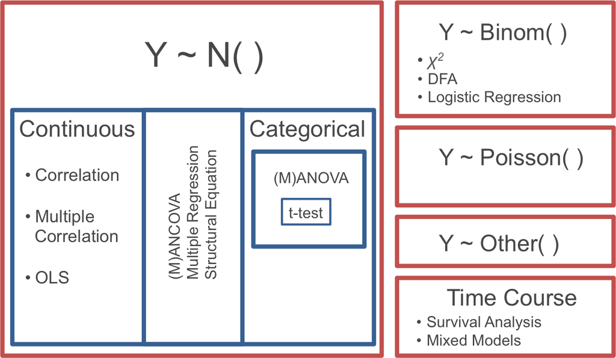

## Problem

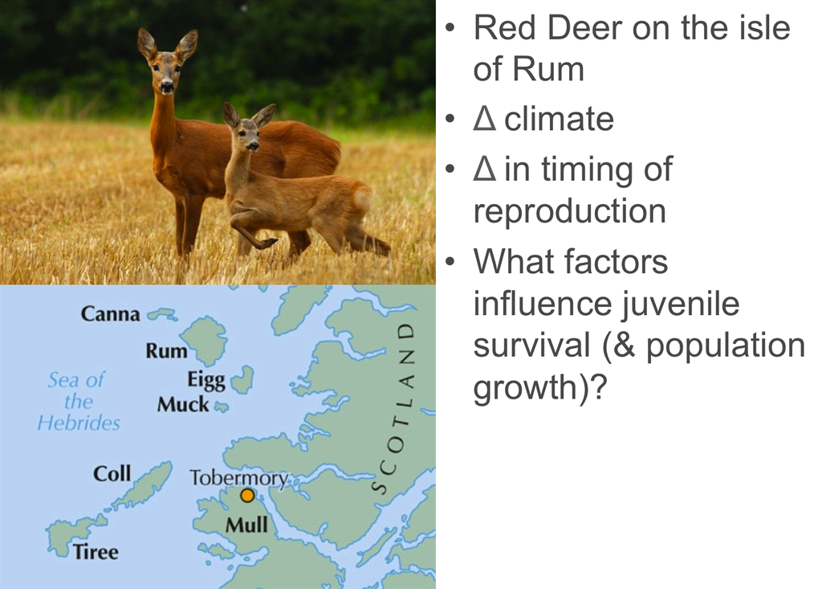

## Prediction

> Outcome: Juvenile Survival

Possible predictors:

- Birth date
- Birth mass
- Year
- Sex
- Maternal fecundity
- Maternal reproductive status
- Maternal age
- Population size
- Temperature (min, max, ave…)
- Rainfall
- Wind speed
- …

## Mixed predictors

Ultimately we will mix arbitrary numbers of categorical and continuous predictors:

- Start thinking beyond "slopes" for continuous predictors
  - How many units of change in the outcome results from a 1 unit increase in the predictor?

For now:

- One categorical predictor
- One continuous predictor ("covariate")

## Energy expenditure in naked mole rats

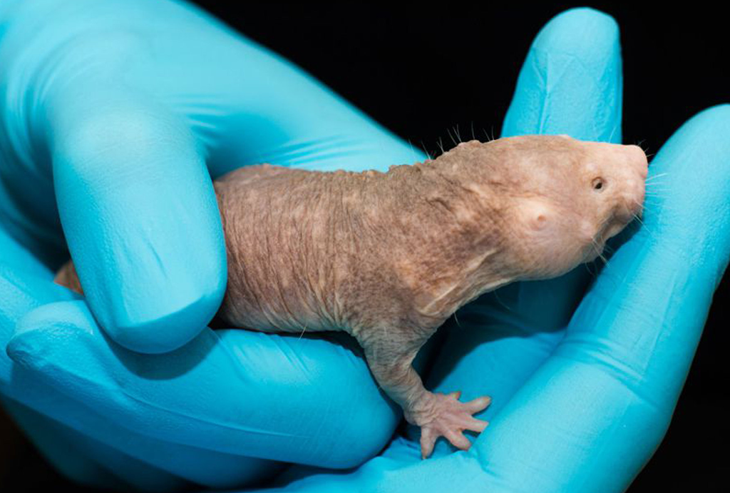

## Energy expenditure in naked mole rats

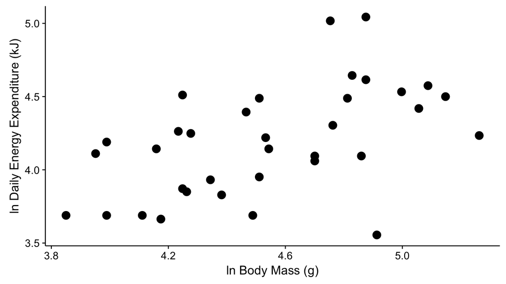

## Energy expenditure in naked mole rats

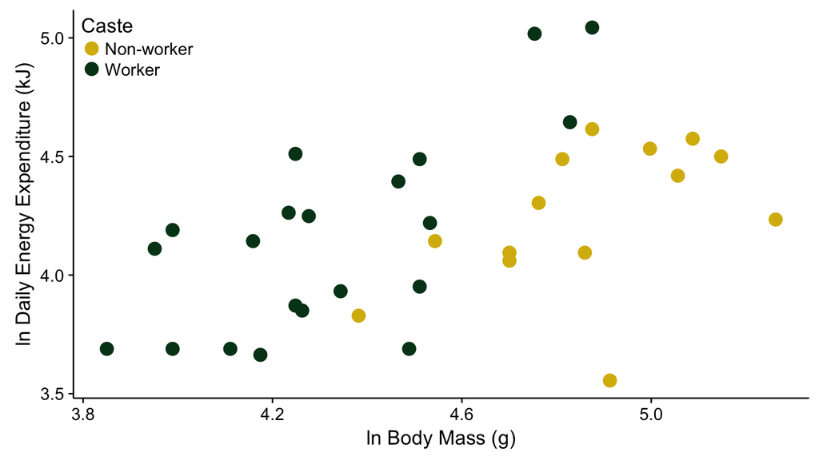

## Energy expenditure in naked mole rats

*ANOVA*:

- Compare mean energy expenditure for non-workers vs. workers
- Ignores the linear relationships with body mass

*Linear regression*:

- Predicts energy expenditure from body mass alone
- Ignores castes, which appear to have different mass-specific energy expenditure

**Account for *both* body mass and caste in predicting energy expenditure**

## Analysis of covariance

1. One categorical predictor
2. One continuous predictor (the *covariate*): allowed to covary with the response variable

## Fit different models to these data

1. Mean (overall mean, no body mass)
2. ANOVA (group mean, no body mass)
3. OLS regression (body mass only, no grouping)
4. ANCOVA, intercepts varying

## 1: Mean

```r
fm1 <- lm(Energy ~ 1, data = M)
```

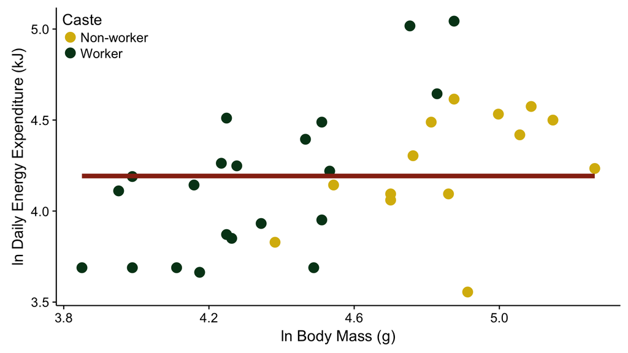

## 1: Mean

```r
summary(fm1)
```

```
##
## Call:
## lm(formula = Energy ~ 1, data = M)
##
## Residuals:
##      Min       1Q   Median       3Q      Max
## -0.63725 -0.29109 -0.00295  0.29604  0.85082
##
## Coefficients:
##             Estimate Std. Error t value Pr(>|t|)
## (Intercept)  4.19260    0.06326   66.27   <2e-16 ***
## ---
## Signif. codes:  0 '***' 0.001 '**' 0.01 '*' 0.05 '.' 0.1 ' ' 1
##
## Residual standard error: 0.3743 on 34 degrees of freedom
```

## 2: ANOVA

```r
fm2 <- lm(Energy ~ Caste, data = M)
```

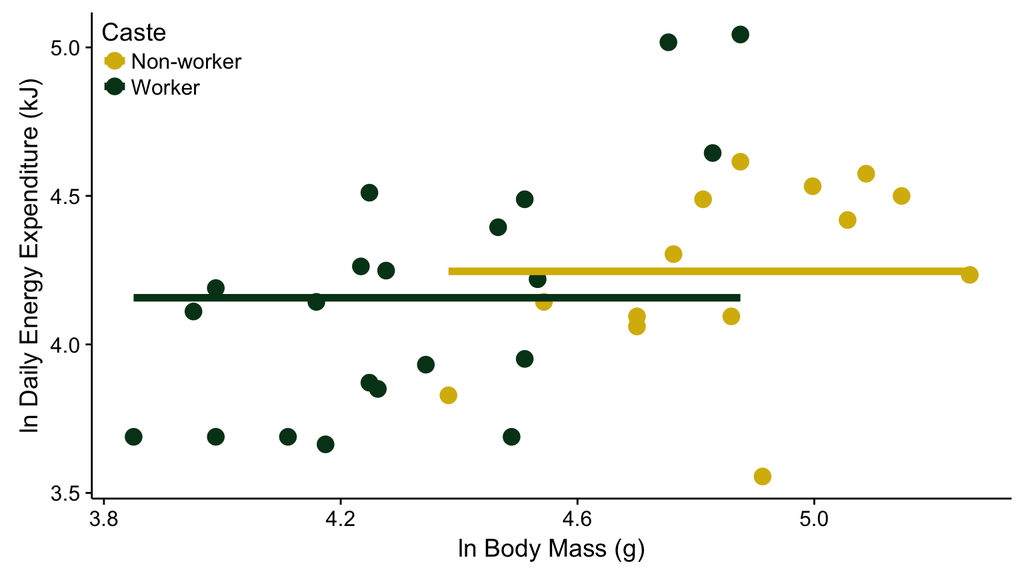

## 2: ANOVA

```r
summary(fm2)
```

```
##
## Call:
## lm(formula = Energy ~ Caste, data = M)
##
## Residuals:
##     Min      1Q  Median      3Q     Max
## -0.6907 -0.2555 -0.0119  0.2482  0.8864
##
## Coefficients:
##             Estimate Std. Error t value Pr(>|t|)
## (Intercept)  4.24601    0.10082  42.115   <2e-16 ***
## CasteWorker -0.08902    0.13016  -0.684    0.499
## ---
## Signif. codes:  0 '***' 0.001 '**' 0.01 '*' 0.05 '.' 0.1 ' ' 1
##
## Residual standard error: 0.3772 on 33 degrees of freedom
## Multiple R-squared:  0.01398,    Adjusted R-squared:  -0.0159
## F-statistic: 0.4677 on 1 and 33 DF,  p-value: 0.4988
```

## 3: OLS regression

```r
fm3 <- lm(Energy ~ Mass, data = M)
```

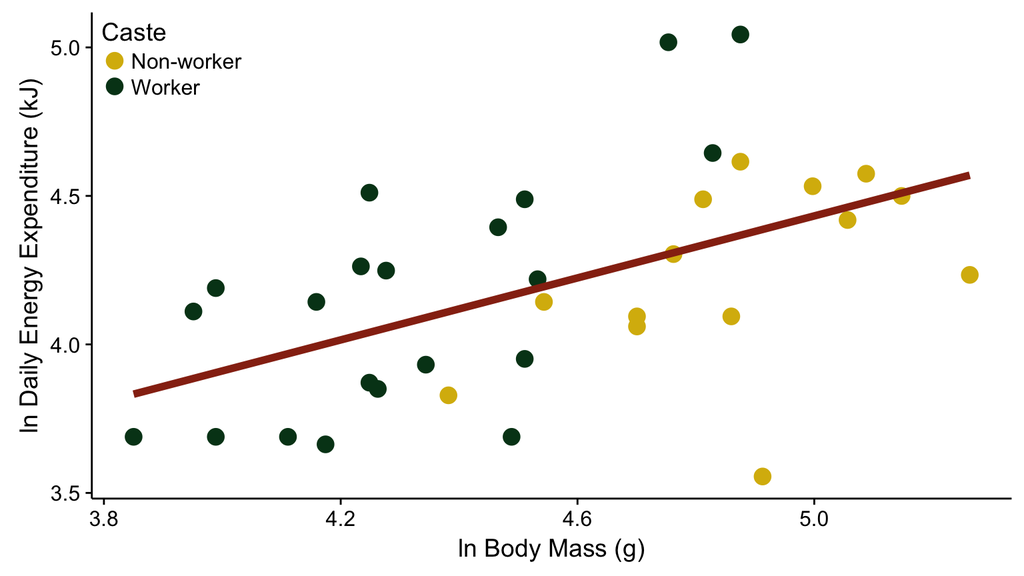

## 3: OLS regression

```r
summary(fm3)
```

```
##
## Call:
## lm(formula = Energy ~ Mass, data = M)
##
## Residuals:
##      Min       1Q   Median       3Q      Max
## -0.83168 -0.21599 -0.00978  0.22767  0.71326
##
## Coefficients:
##             Estimate Std. Error t value Pr(>|t|)
## (Intercept)   1.8233     0.6716   2.715  0.01047 *
## Mass          0.5219     0.1474   3.540  0.00122 **
## ---
## Signif. codes:  0 '***' 0.001 '**' 0.01 '*' 0.05 '.' 0.1 ' ' 1
##
## Residual standard error: 0.3234 on 33 degrees of freedom
## Multiple R-squared:  0.2752, Adjusted R-squared:  0.2532
## F-statistic: 12.53 on 1 and 33 DF,  p-value: 0.001216
```

## 4: ANCOVA, intercepts varying

```r
fm4 <- lm(Energy ~ Mass + Caste, data = M)
```

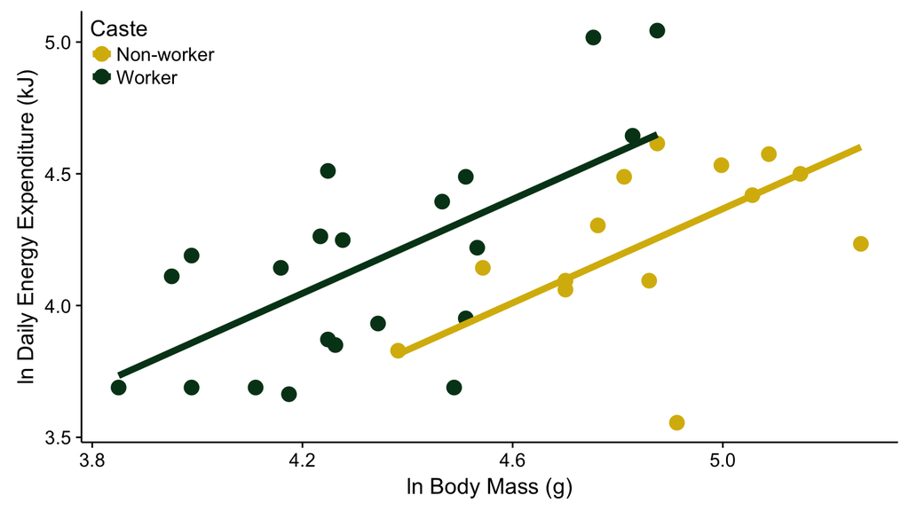

## 4: ANCOVA, intercepts varying

```r
summary(fm4)
```

```
##
## Call:
## lm(formula = Energy ~ Mass + Caste, data = M)
##
## Residuals:
##      Min       1Q   Median       3Q      Max
## -0.73388 -0.19371  0.01317  0.17578  0.47673
##
## Coefficients:
##             Estimate Std. Error t value Pr(>|t|)
## (Intercept) -0.09687    0.94230  -0.103   0.9188
## Mass         0.89282    0.19303   4.625 5.89e-05 ***
## CasteWorker  0.39334    0.14611   2.692   0.0112 *
## ---
## Signif. codes:  0 '***' 0.001 '**' 0.01 '*' 0.05 '.' 0.1 ' ' 1
##
## Residual standard error: 0.2966 on 32 degrees of freedom
## Multiple R-squared:  0.409,  Adjusted R-squared:  0.3721
## F-statistic: 11.07 on 2 and 32 DF,  p-value: 0.0002213
```

## 4: ANCOVA, intercepts varying

```
Coefficients:
            Estimate Std. Error t value Pr(>|t|)
(Intercept) -0.09687    0.94230  -0.103   0.9188
Mass         0.89282    0.19303   4.625 5.89e-05
CasteWorker  0.39334    0.14611   2.692   0.0112
```

- `(Intercept)`: Intercept for non-workers
- `Mass`: Slope for both groups
- `CasteWorker`: *Offset* for the Worker group (difference in intercepts)

## Fit different models to these data

1. Mean (overall mean, no body mass)
2. ANOVA (group mean, no body mass)
3. OLS regression (body mass only, no grouping)
4. ANCOVA, intercepts varying

> Which model is best?

Model comparison in a few weeks…

## Bayesian approach

Data setup:

```r
M_bayes <- M %>%
  mutate(Caste_Worker = if_else(Caste == "Worker", 1, 0)) %>%
  select(-Caste) %>%
  as.data.frame()
head(M_bayes)
```

```
##       Mass   Energy Caste_Worker
## 1 3.850148 3.688879            1
## 2 3.988984 3.688879            1
## 3 4.110874 3.688879            1
## 4 4.174387 3.663562            1
## 5 4.248495 3.871201            1
## 6 4.262680 3.850148            1
```

## Bayesian approach

```r
fm_Bayes <- rethinking::map(
  alist(
    Energy ~ dnorm(mu, sigma),
    mu <-
      a +
      aWorker * Caste_Worker + # 0 when Caste == Non-worker
      bMass * Mass,
    a ~ dnorm(0, 5),
    aWorker ~ dnorm(0, 5),
    bMass ~ dnorm(0, 2),
    sigma ~ dcauchy(0, 2)
  ),
  data = M_bayes,
  start = list(bMass = 0.1, a = 0, aWorker = 0, sigma = 0.1)
)
```

## Bayesian approach

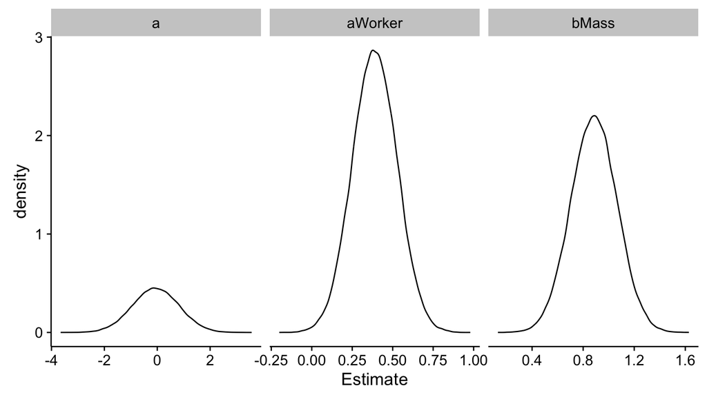

## Bayesian approach

```r
coef(fm4)
```

```
## (Intercept)        Mass CasteWorker
## -0.09686842  0.89281513  0.39334235
```

```r
precis(fm_Bayes)
```

```
##          Mean StdDev  5.5% 94.5%
## bMass    0.88   0.18  0.60  1.17
## a       -0.06   0.88 -1.47  1.35
## aWorker  0.39   0.14  0.17  0.61
## sigma    0.28   0.03  0.23  0.34
```

## Quiz 07-4

Complete Quiz 07-4

Last lecture for this week